# Session 17 Script: R notebook using R markdown to produce a literate program

Joshua Yukich

16 February 2025

Since the code chunk below includes the header argument “echo = FALSE” you will only see its outputs when you compile the dynamic document.

# An example using a paired Student’s *t*-test

This document first includes by direct input data from an experiment in which ten mice were fed an experimental drug and weighed before and after the experiment. The goal was to determine if the mice would gain a meaningful amount of weight before and after the administration of drug. Hence we have ten pairs of weights, each representing the two measurements of weight in each mouse. The code below shows the entry of the data directly, as well as some minor tidying followed by execution of the paired Student’s *t*-test using the data either input as two separate vectors.

```
    Paired t-test

data:  after and before
t = 20.883, df = 9, p-value = 6.2e-09
alternative hypothesis: true mean difference is not equal to 0
95 percent confidence interval:
 173.4219 215.5581
sample estimates:
mean difference
         194.49
```

# Making a plot

The *ggplot* code below will produce a plot which if included in a code chunk will be automatically placed into the document. Adding the “echo = FALSE” argument to the code chunk header makes a clean entry for the plot with only plot output.

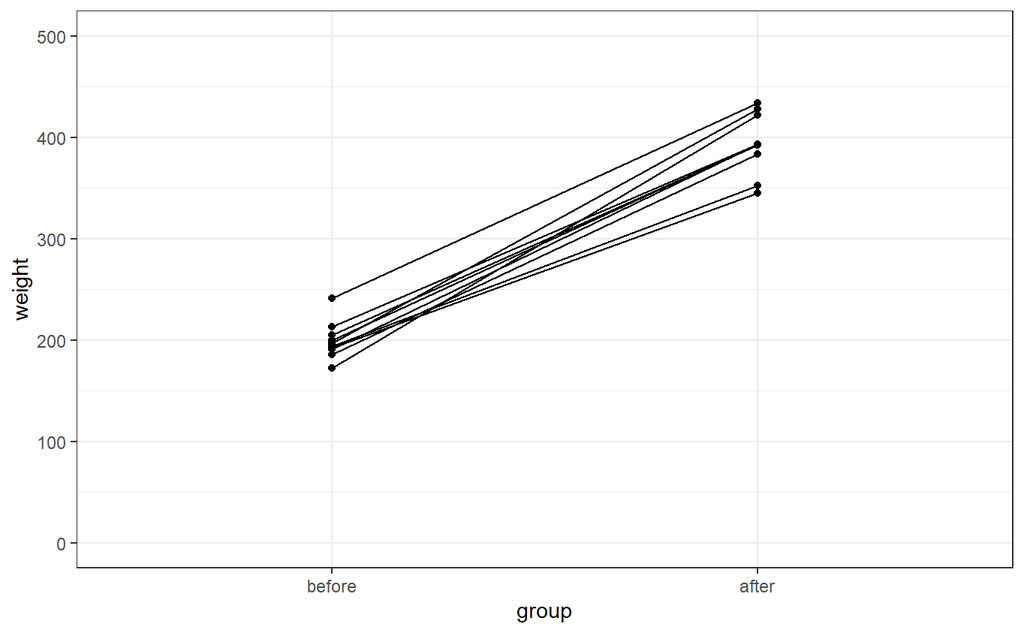

# Including R inline code

The above code chunks only put outputs into the documents as whole sections in a document. From time to time you may want to directly include elements from R directly inside the course of a sentence.

For example: The results of a Student’s paired *t*-test applied to the before and after mice weight dataset were highly significant with an estimated mean of the difference in weight of 194.49 grams (*p*-value < 0.001) between the measurements of weight before and after treatment.